# Football Events

1/2/2018

- In order to perform analysis on different football events, we first create the ERD for the data provided to us
- After creating the tables we answer different questions through SQL queries

### Entity Relationship Diagram

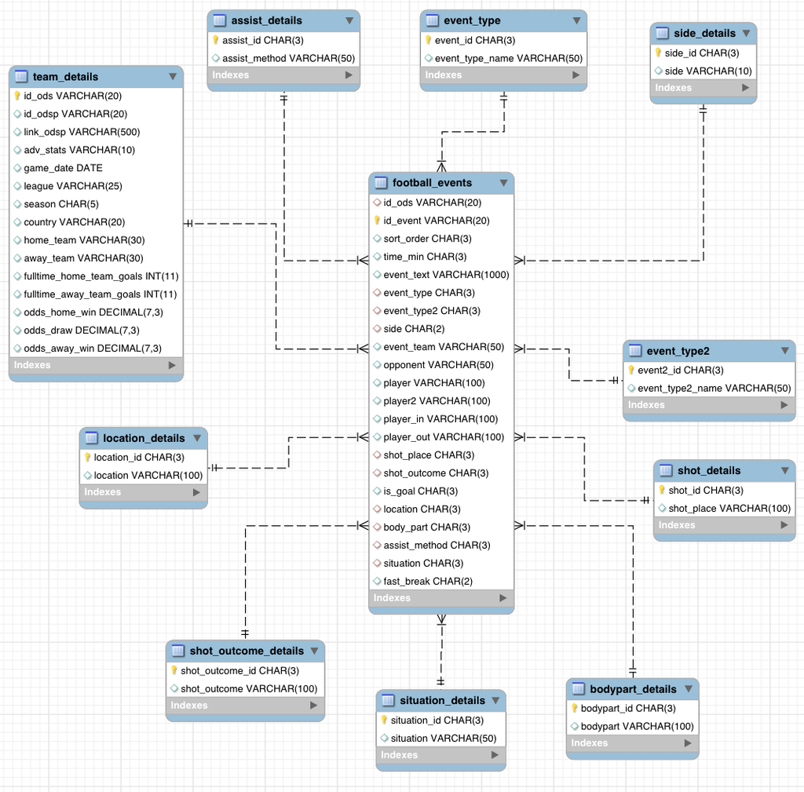

### Create Database

`CREATE DATABASE football_data;`

### Use the database created

`USE football_data;`

### Create Tables

- Create a table containing all the football events

`CREATE TABLE football_events(`  
`id_ods VARCHAR(20),`  
`id_event VARCHAR(20),`  
`sort_order CHAR(3),`  
`time_min CHAR(3),`  
`event_text VARCHAR(1000),`  
`event_type CHAR(3),`  
`event_type2 CHAR(3),`  
`side CHAR(2),`  
`event_team VARCHAR(50),`  
`opponent VARCHAR(50),`  
`player VARCHAR(100),`  
`player2 VARCHAR(100),`  
`player_in VARCHAR(100),`  
`player_out VARCHAR(100),`  
`shot_place CHAR(3),`  
`shot_outcome CHAR(3),`  
`is_goal CHAR(3),`  
`location CHAR(3),`  
`body_part CHAR(3),`  
`assist_method CHAR(3),`  
`situation CHAR(3),`  
`fast_break CHAR(2),`  
`PRIMARY KEY(id_event),`  
`FOREIGN KEY(id_ods) REFERENCES team_details(id_ods),`  
`FOREIGN KEY(event_type) REFERENCES event_type(event_id),`  
`FOREIGN KEY(event_type2) REFERENCES event_type2(event2_id),`  
`FOREIGN KEY(side) REFERENCES side_details(side_id),`  
`FOREIGN KEY(shot_place) REFERENCES shot_details(shot_id),`  
`FOREIGN KEY(shot_outcome) REFERENCES shot_outcome_details(shot_outcome_id),`  
`FOREIGN KEY(location) REFERENCES location_details(location_id),`  
`FOREIGN KEY(body_part) REFERENCES bodypart_details(bodypart_id),`  
`FOREIGN KEY(assist_method) REFERENCES assist_details(assist_id),`  
`FOREIGN KEY(situation) REFERENCES situation_details(situation_id)`  
`);`

- Load the table football events

`LOAD DATA LOCAL INFILE '/Users/Kaul10/Desktop/events.csv'`  
`INTO TABLE football_events`  
`FIELDS TERMINATED BY ','`  
`ENCLOSED BY '"'`  
`LINES TERMINATED BY "\n"`  
`IGNORE 1 ROWS`  
`(id_ods, id_event, sort_order, time_min, event_text, event_type, event_type2, side, event_team,`  
`opponent, player, player2, player_in, player_out, shot_place, shot_outcome, is_goal,`  
`location, body_part, assist_method, situation, @fast_break)`  
`SET fast_break = CAST(@fast_break AS CHAR(3));`

- Create the table that gives details of the event type

`CREATE TABLE event_type(`  
`event_id CHAR(3),`  
`event_type_name VARCHAR(50),`  
`PRIMARY KEY(event_id)`  
`);`

- Load the table event type

`INSERT INTO event_type VALUES('0', 'Announcement'),`  
`('1', 'Attempt'),`  
`('2', 'Corner'),`  
`('3', 'Foul'),`  
`('4', 'Yellow Card'),`  
`('5', 'Second Yellow Card'),`  
`('6', 'Red Card'),`  
`('7', 'Substitution'),`  
`('8', 'Free Kick Won'),`  
`('9', 'Offside'),`  
`('10', 'HAND Ball'),`  
`('11', 'Penalty Conceded');`

- Create the table that gives additional event information

`CREATE TABLE event_type2(`  
`event2_id CHAR(3),`  
`event_type2_name VARCHAR(50),`  
`PRIMARY KEY(event2_id)`  
`);`

- Load the table event type2

`INSERT INTO event_type2 VALUES('12', 'KEY Pass'),`  
`('13', 'Failed Through Ball'),`  
`('14', 'SENDing Off'),`  
`('15', 'Own Goal');`

- Create the table that helps identify home team and away team

`CREATE TABLE side_details(`  
`side_id CHAR(3),`  
`side VARCHAR(10),`  
`PRIMARY KEY(side_id)`  
`);`

- Load the table with side detail information

`INSERT INTO side_details VALUES('1', 'Home'),`  
`('2', 'Away');`

- Create the table that helps give details about the shot taken

`CREATE TABLE shot_details(`  
`shot_id CHAR(3),`  
`shot_place VARCHAR(100),`  
`PRIMARY KEY(shot_id)`  
`);`

- Load the table with shot information

`INSERT INTO shot_details VALUES('1', 'Bit Too High'),`  
`('2', 'Blocked'),`  
`('3', 'Bottom Left Corner'),`  
`('4', 'Bottom Right Corner'),`  
`('5', 'Center of the Goal'),`  
`('6', 'High AND Wide'),`  
`('7', 'Hits the Bar'),`  
`('8', 'Misses to the Left'),`  
`('9', 'Misses to the Right'),`  
`('10', 'Too High'),`  
`('11', 'Top Center of the Goal'),`  
`('12', 'Top Left Corner'),`  
`('13', 'Top Right Corner');`

- Create the table that gives details about the outcome of the shot

`CREATE TABLE shot_outcome_details(`  
`shot_outcome_id CHAR(3),`  
`shot_outcome VARCHAR(100),`  
`PRIMARY KEY(shot_outcome_id)`  
`);`

- Load the table with shot outcome information

`INSERT INTO shot_outcome_details VALUES('1', 'On Target'),`  
`('2', 'Off Target'),`  
`('3', 'Blocked'),`  
`('4', 'hit the Bar');`

- Create the table that gives us the details of the location

`CREATE TABLE location_details(`  
`location_id CHAR(3),`  
`location VARCHAR(100),`  
`PRIMARY KEY(location_id)`  
`);`

- Load the table with location information

`INSERT INTO location_details VALUES('1', 'Attacking Half'),`  
`('2', 'Defensive Half'),`  
`('3', 'Center of the Box'),`  
`('4', 'Left Wing'),`  
`('5', 'Right Wing'),`  
`('6', 'Difficult Angle and Long Range'),`  
`('7', 'Difficult Angle on the Left'),`  
`('8', 'Difficult Angle on the Right'),`  
`('9', 'Left Side of the Box'),`  
`('10', 'Left Side of the Six Yard Box'),`  
`('11', 'Right Side of the Box'),`  
`('12', 'left Side of the Six Yard Box'),`  
`('13', 'Very Close Range'),`  
`('14', 'Penalty Spot'),`  
`('15', 'Outside the Box'),`  
`('16', 'Long Range'),`  
`('17', 'More than 35 Yards'),`  
`('18', 'More than 40 Yards'),`  
`('19', 'Not Recorded');`

- Create the table that gives the details of which body part the ball hit

`CREATE TABLE bodypart_details(`  
`bodypart_id CHAR(3),`  
`bodypart VARCHAR(100),`  
`PRIMARY KEY(bodypart_id)`  
`);`

- Load the table with body part information

`INSERT INTO bodypart_details VALUES('1', 'Right Foot'),`  
`('2', 'Left Foot'),`  
`('3', 'Head');`

- Create the table that gives details about what the assist method was

`CREATE TABLE assist_details(`  
`assist_id CHAR(3),`  
`assist_method VARCHAR(50),`  
`PRIMARY KEY(assist_id)`  
`);`

- Load the table with assist method

`INSERT INTO assist_details VALUES('0', 'None'),`  
`('1', 'Pass'),`  
`('2', 'Cross'),`  
`('3', 'Headed Pass'),`  
`('4', 'Through Ball');`

- Create the table that gives details about the situation

`CREATE TABLE situation_details(`  
`situation_id CHAR(3),`  
`situation VARCHAR(50),`  
`PRIMARY KEY(situation_id)`  
`);`

- Load the table with situation which let to the event

`INSERT INTO situation_details VALUES('1', 'Open Play'),`  
`('2', 'Set Piece'),`  
`('3', 'Corner'),`  
`('4', 'Free Kick');`

- Create the table that gives details about the team, league, goals and odds

`CREATE TABLE team_details(`  
`id_ods VARCHAR(20),`  
`id_odsp VARCHAR(20),`  
`link_odsp VARCHAR(500),`  
`adv_stats VARCHAR(10),`  
`game_date date,`  
`league VARCHAR(25),`  
`season CHAR(5),`  
`country VARCHAR(20),`  
`home_team VARCHAR(30),`  
`away_team VARCHAR(30),`  
`fulltime_home_team_goals int,`  
`fulltime_away_team_goals int,`  
`odds_home_win decimal(7,3),`  
`odds_draw decimal(7,3),`  
`odds_away_win decimal(7,3),`  
`PRIMARY KEY(id_ods)`  
`);`

- Load the data into the team details table

`LOAD DATA LOCAL INFILE '/Users/Kaul10/Desktop/ginf.csv'`  
`INTO TABLE team_details`  
`FIELDS TERMINATED BY ','`  
`ENCLOSED BY '"'`  
`LINES TERMINATED BY '\n'`  
`IGNORE 1 ROWS`  
`(id_ods, id_odsp, link_odsp, adv_stats, @game_date, league, season, country, home_team,`  
`away_team, fulltime_home_team_goals, fulltime_away_team_goals, odds_home_win,`  
`odds_draw, odds_away_win)`  
`SET game_date = STR_TO_DATE(@game_date, '%m/%d/%y');`

### SQL Queries

`WITH football_events_cte AS(`  
`SELECT id_ods, sort_order, event_text, event_type, player, player2, player_in, player_out FROM football_events`  
`),`

`team_details_cte AS(`  
`SELECT id_ods, season, home_team, away_team FROM team_details`  
`WHERE 1 = 1`  
`AND league = 'EPL'`  
`--AND season = '2015'`  
`),`

`event_type1_cte AS(`  
`SELECT * FROM event_type`  
`),`

`event_type2_cte AS(`  
`SELECT * FROM event_type2`  
`),`

`events_hazard_all AS(`  
`SELECT fce.*, tdc.* FROM football_events_cte fce`  
`INNER JOIN team_details_cte tdc`  
`on fce.id_ods = tdc.id_ods`  
`WHERE 1 = 1`  
`AND player LIKE '%hazard%'`  
`OR player2 LIKE '%hazard%'`  
`OR player_in LIKE '%hazard%'`  
`OR player_out LIKE '%hazard%'`  
`)`

`SELECT event_type_name, season, COUNT(*) AS event_occurence FROM events_hazard_all eh`  
`LEFT OUTER JOIN event_type1_cte etc1`  
`ON eh.event_type = etc1.event_id`  
`LEFT OUTER JOIN event_type2_cte etc2`  
`ON eh.event_type = etc2.event2_id`  
`WHERE 1 = 1`  
`GROUP BY event_type_name, season`  
`ORDER BY event_type_name, season ASC;`

#### Of all the events that Hazard was involved in, how many goals and assists was he involved with

`WITH football_events_cte AS(`  
`SELECT id_ods, sort_order, event_text, event_type, player, player2, player_in, player_out, assist_method, is_goal`  
`FROM football_events`  
`WHERE 1 = 1`  
`),`

`team_details_cte AS(`  
`SELECT id_ods, season, home_team, away_team`  
`FROM team_details`  
`WHERE 1 = 1`  
`AND league = 'EPL'`  
`),`

`events_hazard_all AS(`  
`SELECT fce.*, tdc.* FROM football_events_cte fce`  
`INNER JOIN team_details_cte tdc`  
`on fce.id_ods = tdc.id_ods`  
`WHERE 1 = 1`  
`AND (player LIKE '%eden hazard%' or player2 LIKE '%eden hazard%' or player_in LIKE '%eden hazard%' or player_out LIKE '%eden hazard%')`  
`)`

`final_data as(`  
`select event_text, player, player2, case when player like '%eden hazard%' then 'goal' when player2 like '%eden hazard%' then 'assist' else 'none' end as player_action from events_hazard_all`  
`where 1 = 1`  
`and is_goal = 1`  
`and (player like '%hazard%' or player2 like '%hazard%')`  
`)`

`select player_action, count(*) as occurences from final_data;`

#### Distribution of all different types of events for Chelsea in each season

`WITH football_events_cte AS(`  
`SELECT id_ods, sort_order, event_text, event_type, player, player2, player_in, player_out, assist_method, is_goal`  
`FROM football_events`  
`WHERE 1 = 1`  
`),`

`team_details_cte AS(`  
`SELECT id_ods, season, home_team, away_team`  
`FROM team_details`  
`WHERE 1 = 1`  
`AND league = 'EPL'`  
`),`

`event_type1_cte AS(`  
`SELECT * FROM event_type`  
`),`

`event_type2_cte AS(`  
`SELECT * FROM event_type2`  
`),`

`events_team_all AS(`  
`SELECT fce.*, tdc.*, etc1.*, etc2.* FROM football_events_cte fce`  
`INNER JOIN team_details_cte tdc`  
`ON fce.id_ods = tdc.id_ods`  
`LEFT OUTER JOIN event_type1_cte etc1`  
`ON fce.event_type = etc1.event_id`  
`LEFT OUTER JOIN event_type2_cte etc2`  
`ON fce.event_type = etc2.event2_id`  
`WHERE 1 = 1`  
`AND (home_team LIKE '%ChELSEa%' or away_team LIKE '%ChELSEa%')`  
`),`

`final_data AS(`  
`SELECT season, CASE WHEN event_type2_name IS NOT NULL THEN event_type2_name ELSE event_type_name END AS event_name`  
`FROM events_team_all`  
`)`

`SELECT season, event_name, COUNT(*) AS occurences FROM final_data`  
`GROUP BY event_name, season`  
`ORDER BY event_name ASC, season ASC;`

#### Distribution of number of goals by league in each season that helps us find out which has been the most exciting league each season

`WITH football_events_cte AS(`  
`SELECT id_ods, sort_order, event_text, event_type, player, player2, player_in, player_out, assist_method, is_goal`  
`FROM football_events`  
`WHERE 1 = 1`  
`),`

`team_details_cte AS(`  
`SELECT id_ods, season, home_team, away_team, league`  
`FROM team_details`  
`WHERE 1 = 1`  
`),`

`final_data AS(`  
`SELECT * FROM football_events_cte fec`  
`INNER JOIN team_details_cte tdc`  
`ON fec.id_ods = tdc.id_ods`  
`WHERE 1 = 1`  
`AND is_goal = 1`  
`)`

`SELECT league, season, COUNT(is_goal) AS goals_scored FROM final_data`  
`GROUP BY league, season`  
`ORDER BY season, league;`

#### Distribution of te different assist methods for Cesc Fabregas in the different seasons

`WITH football_events_cte AS(`  
`SELECT * FROM football_events`  
`WHERE 1 = 1`  
`AND is_goal = 1`  
`AND player2 LIKE '%fabregas%'`  
`),`

`team_details_cte AS(`  
`SELECT * FROM team_details`  
`WHERE 1 = 1`  
`),`

`assist_details_cte AS(`  
`SELECT * FROM assist_details`  
`),`

`final_data AS(`  
`SELECT tdc.season, tdc.league, adc.assist_method FROM football_events_cte fec`  
`INNER JOIN team_details_cte tdc`  
`ON fec.id_ods = tdc.id_ods`  
`LEFT OUTER JOIN assist_details_cte adc`  
`ON fec.assist_method = adc.assist_id`  
`)`

`SELECT season, assist_method, COUNT(*) as occurences FROM final_data`  
`GROUP BY season, assist_method`  
`ORDER BY season ASC;`

#### Who is the best player in the world? Messi or Ronaldo. We can compare, by season, the two by looking at which body part they used to score the goals - Right Foot, Left Foot, Head

`WITH football_events_cte AS(`  
`SELECT * FROM football_events`  
`WHERE 1 = 1`  
`AND is_goal = 1`  
`AND (player LIKE '%cristiano ronaldo%' OR player LIKE '%messi%')`  
`--AND (player2 LIKE '%cristiano ronaldo%' or player LIKE '%messi%')`  
`),`

`team_details_cte AS(`  
`SELECT * FROM team_details`  
`WHERE 1 = 1`  
`),`

`bodypart_details_cte AS(`  
`SELECT * FROM bodypart_details`  
`),`

`final_data AS(`  
`SELECT tdc.season, tdc.league, bdc.bodypart, fec.player, fec.player2 FROM football_events_cte fec`  
`INNER JOIN team_details_cte tdc`  
`ON fec.id_ods = tdc.id_ods`  
`LEFT OUTER JOIN bodypart_details_cte bdc`  
`ON fec.body_part = bdc.bodypart_id`  
`)`

`SELECT season, player, bodypart, COUNT(*) FROM final_data`  
`GROUP BY season, bodypart, player`  
`ORDER BY season ASC, bodypart ASC;`

#### How many goalkeeper saves were made in each season for each league to see where the goalkepers have performed the best or have faced the most competition from strikers

`WITH football_events_cte AS(`  
`SELECT * FROM football_events`  
`WHERE 1 = 1`  
`AND shot_outcome IS NOT NULL`  
`),`

`team_details_cte AS(`  
`SELECT * FROM team_details`  
`WHERE 1 = 1`  
`),`

`shot_outcome_details_cte AS(`  
`SELECT * FROM shot_outcome_details`  
`),`

`events_team_data AS(`  
`SELECT fec.*, tdc.*, sodc.shot_outcome_id, sodc.shot_outcome AS shot_status FROM football_events_cte fec`  
`INNER JOIN team_details_cte tdc`  
`ON fec.id_ods = tdc.id_ods`  
`LEFT OUTER JOIN shot_outcome_details_cte sodc`  
`ON sodc.shot_outcome_id = fec.shot_outcome`  
`),`

`goalie_data AS(`  
`SELECT season, league, opponent, shot_status, CASE WHEN shot_status LIKE '%On Target%' OR shot_status LIKE '%Blocked%' THEN 1 ELSE 0 END AS shot_outcome FROM events_team_data`  
`WHERE 1 = 1`  
`AND shot_outcome_id IS NOT NULL`  
`AND is_goal = 0`  
`),`

`final_data AS(`  
`SELECT * FROM goalie_data`  
`WHERE 1 = 1`  
`AND shot_outcome = 1`  
`)`

`SELECT season, league, opponent, COUNT(shot_outcome) AS saves`  
`FROM final_data`  
`GROUP BY season, league, opponent`  
`ORDER BY season ASC, league ASC, COUNT(shot_outcome) DESC`  
`limit 30;`

#### Different situations in which the end result was a goal - Corner, Open Play, Set Piece

`WITH football_events_cte AS(`  
`SELECT * FROM football_events`  
`WHERE 1 = 1`  
`),`

`team_details_cte AS(`  
`SELECT * FROM team_details`  
`WHERE 1 = 1`  
`),`

`situation_details_cte AS(`  
`SELECT situation_id, situation AS actual_situation FROM situation_details`  
`),`

`final_data AS(`  
`SELECT fec.*, tdc.*, sdc.* FROM football_events_cte fec`  
`INNER JOIN team_details_cte tdc`  
`ON fec.id_ods = tdc.id_ods`  
`LEFT OUTER JOIN situation_details_cte sdc`  
`ON fec.situation = sdc.situation_id`  
`WHERE 1 = 1`  
`AND actual_situation IS NOT NULL`  
`AND is_goal = 1`  
`AND event_team LIKE '%ChELSEa%'`  
`)`

`SELECT season, actual_situation, COUNT(*) AS occurences`  
`FROM final_data`  
`GROUP BY season, actual_situation`  
`ORDER BY season ASC;`

#### Check the Free Kick and Penalty conversion data for Ronaldo and Messi to further add to their best player status

`WITH football_events_cte AS(`  
`SELECT * FROM football_events`  
`WHERE 1 = 1`  
`),`

`team_details_cte AS(`  
`SELECT * FROM team_details`  
`WHERE 1 = 1`  
`),`

`location_details_cte AS(`  
`SELECT location_id, location AS actual_location FROM location_details`  
`),`

`situation_details_cte AS(`  
`SELECT situation_id, situation AS actual_situation FROM situation_details`  
`),`

`final_data AS(`  
`SELECT fec.*, tdc.*, ldc.*, sdc.* FROM football_events_cte fec`  
`INNER JOIN team_details_cte tdc`  
`ON fec.id_ods = tdc.id_ods`  
`LEFT OUTER JOIN location_details_cte ldc`  
`ON ldc.location_id = fec.location`  
`LEFT OUTER JOIN situation_details_cte sdc`  
`ON sdc.situation_id = fec.situation`  
`WHERE 1 = 1`  
`AND is_goal = 1`  
`AND (player LIKE '%cristiano%' or player LIKE '%messi%')`  
`),`

`final_agg_data AS(`  
`SELECT season, player, actual_location, actual_situation,`  
`CASE WHEN actual_location LIKE '%Penalty%' THEN 'Penalty' WHEN actual_situation LIKE '%Free%' THEN 'Free Kick' ELSE 'Other' END AS set_piece`  
`FROM final_data`  
`)`

`SELECT season, player, set_piece, COUNT(*) AS occurence FROM final_agg_data`  
`WHERE 1 = 1`  
`AND set_piece NOT LIKE '%Other%'`  
`GROUP BY season, set_piece, player`  
`ORDER BY season, set_piece, player;`

`WITH football_events_cte AS(`  
`SELECT * FROM football_events`  
`WHERE 1 = 1`  
`),`

`team_details_cte AS(`  
`SELECT * FROM team_details`  
`WHERE 1 = 1`  
`),`

`location_details_cte AS(`  
`SELECT location_id, location AS actual_location FROM location_details`  
`WHERE 1 = 1`  
`),`

`final_data AS(`  
`SELECT fec.*, tdc.*, ldc.* FROM football_events_cte fec`  
`INNER JOIN team_details_cte tdc`  
`ON fec.id_ods = tdc.id_ods`  
`LEFT OUTER JOIN location_details_cte ldc`  
`ON ldc.location_id = fec.location`  
`WHERE 1 = 1`  
`AND is_goal = 1`  
`--AND (player LIKE '%hazard%' or player LIKE '%messi%')`  
`),`

`final_agg_data AS(`  
`SELECT season, league, actual_location`  
`FROM final_data`  
`WHERE 1 = 1`  
`)`

`SELECT season, league, actual_location, COUNT(*) AS occurence FROM final_agg_data`  
`WHERE 1 = 1`  
`AND (actual_location LIKE '%Long Range%' OR actual_location LIKE '%More than 35 Yards%' OR actual_location LIKE '%More than 40 Yards%')`  
`GROUP BY season, league, actual_location`  
`ORDER BY season, actual_location;`

`WITH football_events_cte AS(`  
`SELECT * FROM football_events`  
`WHERE 1 = 1`  
`),`

`team_details_cte AS(`  
`SELECT * FROM team_details`  
`WHERE 1 = 1`  
`),`

`event_type_cte AS(`  
`SELECT * FROM event_type`  
`),`

`football_team_details AS(`  
`SELECT fec.*, tdc.*, etc.* FROM football_events_cte fec`  
`INNER JOIN team_details_cte tdc`  
`ON fec.id_ods = tdc.id_ods`  
`LEFT OUTER JOIN event_type_cte etc`  
`ON fec.event_type = etc.event_id`  
`WHERE 1 = 1`  
`AND event_type_name LIKE '%Yellow card%'`  
`)`

`SELECT season, league, event_type_name, player, COUNT(*) AS occurence FROM football_team_details`  
`GROUP BY season, league, event_type_name, player`  
`HAVING COUNT(*) >= 10`  
`ORDER BY season ASC, COUNT(*) DESC;`

#### Players with most Red Cards or Double Yellow Cards in the different leagues

`WITH football_events_cte AS(`  
`SELECT * FROM football_events`  
`WHERE 1 = 1`  
`),`

`team_details_cte AS(`  
`SELECT * FROM team_details`  
`WHERE 1 = 1`  
`),`

`event_type_cte AS(`  
`SELECT * FROM event_type`  
`),`

`football_team_details AS(`  
`SELECT fec.*, tdc.*, etc.* FROM football_events_cte fec`  
`INNER JOIN team_details_cte tdc`  
`ON fec.id_ods = tdc.id_ods`  
`LEFT OUTER JOIN event_type_cte etc`  
`ON fec.event_type = etc.event_id`  
`WHERE 1 = 1`  
`AND (event_type_name LIKE '%Red card%' OR event_type_name LIKE '%Second yellow card%')`  
`)`

`SELECT season, league, event_type_name, player, COUNT(*) AS occurence FROM football_team_details`  
`GROUP BY season, league, event_type_name, player`  
`HAVING COUNT(*) > 1`  
`ORDER BY season ASC, COUNT(*) DESC;`

#### Players that were fouled the most number of times in each season

`WITH football_events_cte AS(`  
`SELECT * FROM football_events`  
`WHERE 1 = 1`  
`),`

`team_details_cte AS(`  
`SELECT * FROM team_details`  
`WHERE 1 = 1`  
`),`

`event_type_cte AS(`  
`SELECT * FROM event_type`  
`),`

`football_team_details AS(`  
`SELECT fec.*, tdc.*, etc.* FROM football_events_cte fec`  
`INNER JOIN team_details_cte tdc`  
`ON fec.id_ods = tdc.id_ods`  
`LEFT OUTER JOIN event_type_cte etc`  
`ON fec.event_type = etc.event_id`  
`WHERE 1 = 1`  
`AND event_type_name LIKE '%Kick%'`  
`)`

`SELECT season, league, player, COUNT(*) AS occurence FROM football_team_details`  
`GROUP BY season, league, player`  
`HAVING COUNT(*) > 75`  
`ORDER BY season ASC, COUNT(*) DESC;`

#### Players that had the most number of offside decisions against them in each year in the different leagues

`WITH football_events_cte AS(`  
`SELECT * FROM football_events`  
`WHERE 1 = 1`  
`),`

`team_details_cte AS(`  
`SELECT * FROM team_details`  
`WHERE 1 = 1`  
`),`

`event_type_cte AS(`  
`SELECT * FROM event_type`  
`),`

`football_team_details AS(`  
`SELECT fec.*, tdc.*, etc.* FROM football_events_cte fec`  
`INNER JOIN team_details_cte tdc`  
`ON fec.id_ods = tdc.id_ods`  
`LEFT OUTER JOIN event_type_cte etc`  
`ON fec.event_type = etc.event_id`  
`WHERE 1 = 1`  
`AND event_type_name LIKE '%Offside%'`  
`)`

`SELECT season, league, player, COUNT(*) AS occurence FROM football_team_details`  
`GROUP BY season, league, player`  
`HAVING COUNT(*) > 50`  
`ORDER BY season ASC, COUNT(*) DESC;`